# formatieveRNAseq

Wouter

4-4-2022

### onderdeel 1a introductie

De onderzoeksvraag is: wat is het effect van MYC, OCT3/4, SOX2 en KLF4 op de genexpressie van fibroblasten en lijken deze hierna meer op stamcellen?

### onderdeel 1b fastqfile downloaden

```bash
for id in $(cat textfile.txt)

do

fastq-dump --split-3 --outdir '/home/wouter.verra/daur2/rnaseq_iPSC/fastq/.' --gzip $id

done
```

### onderdeel 1c fastqc conclusie

Omdat bij de per sequence quality scores de piek aan de rechterkant zit kunnen we conluderen dat de read een hoge gemiddelde Phred score hebben.

### onderdeel 1d alignment

```r
# Create object with location of fastq files
fastq_dir <- "/home/daur2/rnaseq/rnaseq_ipsc/fastq/"

# Create object with basename of index files
hg38_index <- "/home/daur2/rnaseq/hg38_index/hg38_index"

# Create object with output dir for bam files
bam_dir <- "/home/daur2/rnaseq/rnaseq_ipsc/bam/"

# Create a vector with sample numbers
samples <- list.files(fastq_dir, pattern = "_[12].fastq.gz") %>%
  str_remove(pattern = "_[12].fastq.gz") %>%
  unique()

# Align the reads in the fastq files
alignment_statistics <- align(

  index = hg38_index,
  readfile1 = paste0(fastq_dir, samples, "_1.fastq.gz"),
  readfile2 = paste0(fastq_dir, samples, "_2.fastq.gz"),
  type = "rna", input_format = "gzFASTQ", output_format = "BAM",
  output_file = paste0(bam_dir, samples, ".bam"),

  # report only uniquely mapping reads
  unique = TRUE,

  # number of CPU threads
  nthreads = 10

)

# Store the alignment statistics as R object
saveRDS(alignment_statistics, file = paste0(bam_dir, "alignment_statistics.rds"))
```

### onderdeel 1e alignment controle

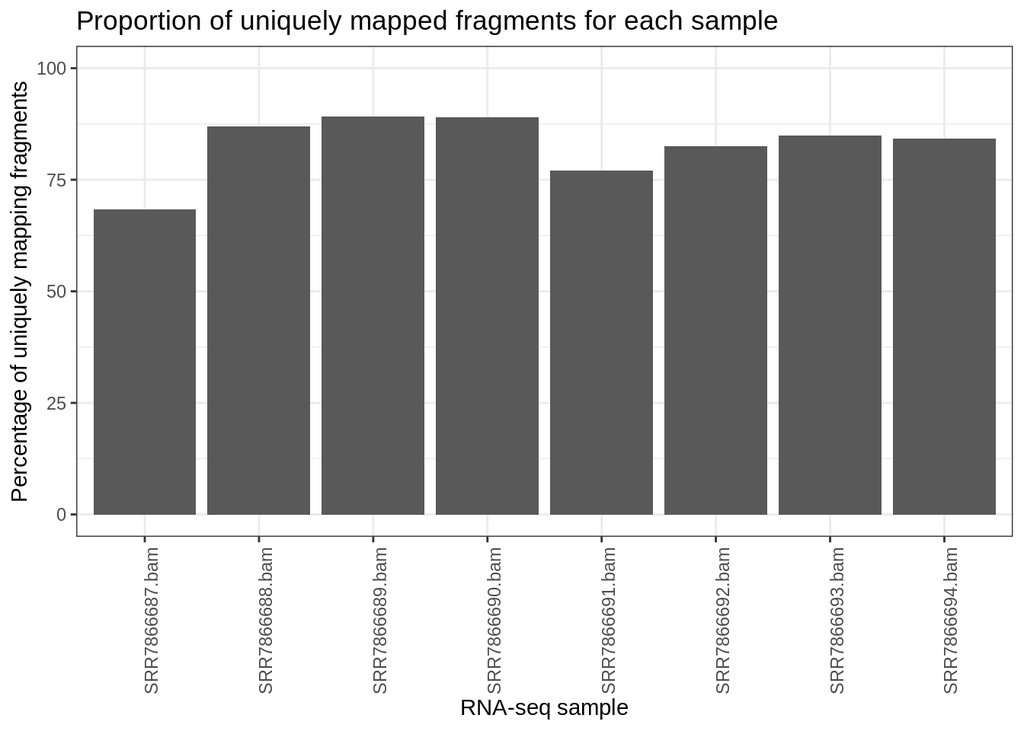

```r
# Read the file into R
alignment_stats <- readRDS("/home/daur2/rnaseq/rnaseq_ipsc/bam/alignment_statistics.rds")

# Calculate the percentage of uniquely mapping fragments
alignment_stats_t <- alignment_stats %>%
  t %>%
  as_tibble() %>%
  mutate(bamfile=colnames(alignment_stats)) %>%
  mutate(perc_unique_mapped = Uniquely_mapped_fragments/Total_fragments*100)

# Plot the percentages in a bar graph
alignment_stats_t %>% ggplot(aes(x = bamfile, y = perc_unique_mapped)) +
  geom_col() +
  ggtitle("Proportion of uniquely mapped fragments for each sample") +
  xlab("RNA-seq sample") +
  ylab("Percentage of uniquely mapping fragments") +
  theme_bw() +
  theme(axis.text.x = element_text(angle = 90)) +
  coord_cartesian (ylim =c(0,100))
```

### onderdeel 2a maak count table

```r
# Create object with input dir for bam files
bam_dir <- "/home/daur2/rnaseq/rnaseq_ipsc/bam/"

# Create object with output dir for count tables
counts_dir <- "/home/daur2/rnaseq/rnaseq_ipsc/counts/"

# Create vector with names of bam files
bam_files <- list.files(bam_dir, pattern = ".*\\.bam$", full.names = TRUE)

# Count the reads per gene using the in-built NCBI RefSeq annotations
read_counts <- featureCounts(

  files = bam_files,
  annot.inbuilt = "hg38",
  useMetaFeatures = TRUE,
  strandSpecific = 0,
  isPairedEnd = TRUE,
  countReadPairs = TRUE,
  nthreads = 10
)
```

### onderdeel 2b controleer count table

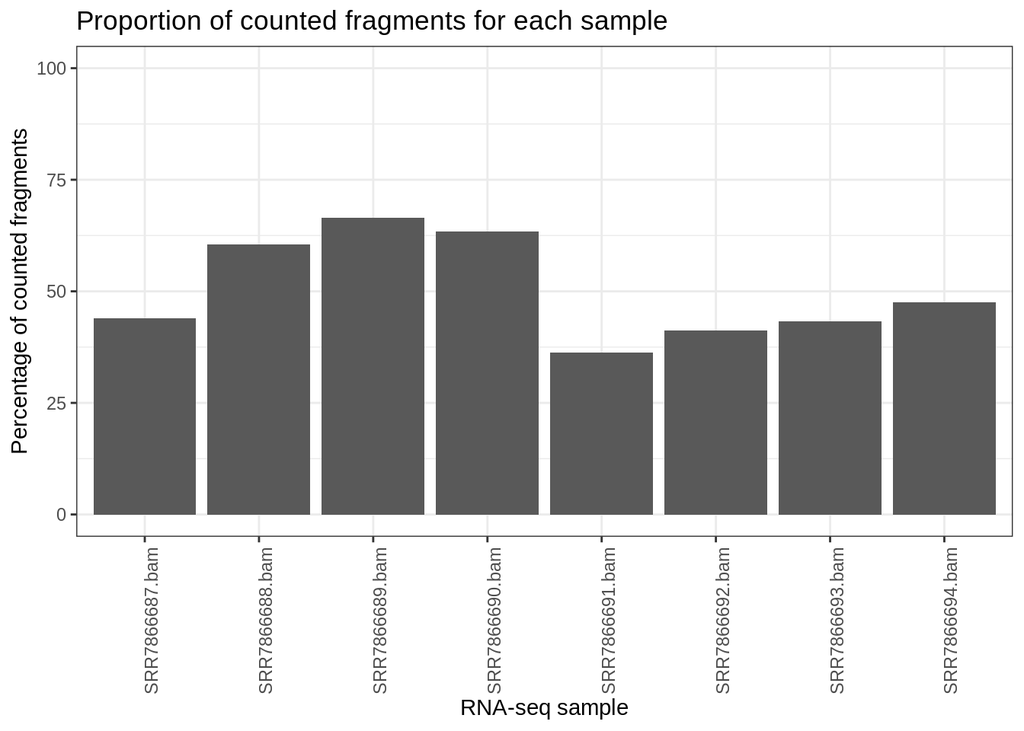

```r
# obtain list from directory
read_counts <- readRDS("/home/daur2/rnaseq/rnaseq_ipsc/counts/read_counts.rds")

# Obtain the dataframe with the statistics
count_stats <- read_counts$stat

# Convert first column to rownames
rownames(count_stats) <- count_stats$Status
count_stats$Status <- NULL

# Calculate the percentage of uniquely counting fragments
count_stats_t <- count_stats %>%
  t %>%
  as_tibble() %>%
  mutate(bamfile=colnames(count_stats)) %>%
  mutate(Total=colSums(count_stats)) %>%
  mutate(perc_assigned = Assigned/Total*100)

# Plot the percentages in a bar graph
count_stats_t %>% ggplot(aes(x = bamfile, y = perc_assigned)) +
  geom_col() +
  ggtitle("Proportion of counted fragments for each sample") +
  xlab("RNA-seq sample") +
  ylab("Percentage of counted fragments") +
  theme_bw() +
  theme(axis.text.x = element_text(angle = 90)) +
  coord_cartesian (ylim =c(0,100))
```

### onderdeel 2c maak DESeqDataSet

```r
# Obtain the count matrix
count_matrix <- read_counts$counts

# Import the sample data
metadata <- read_csv("/home/daur2/rnaseq/rnaseq_ipsc/ipsc_sampledata.csv")
# Convert the metadata to dataframe object
metadata <- as.data.frame(metadata)

# Add rownames to the metadata dataframe
rownames(metadata) <- paste0(metadata$Run, ".bam")

# Show first lines of metadata object
head(metadata)
```

```
##                       Run Assay Type AvgSpotLen      Bases  BioProject
## SRR7866687.bam SRR7866687    RNA-Seq         84 3100625705 PRJNA491516
## SRR7866688.bam SRR7866688    RNA-Seq         85 2678322059 PRJNA491516
## SRR7866689.bam SRR7866689    RNA-Seq         85 1617791810 PRJNA491516
## SRR7866690.bam SRR7866690    RNA-Seq         85 2335911220 PRJNA491516
## SRR7866691.bam SRR7866691    RNA-Seq         84 2388288424 PRJNA491516
## SRR7866692.bam SRR7866692    RNA-Seq         85 2538209760 PRJNA491516
##                   BioSample      Bytes
## SRR7866687.bam SAMN10079885 1380751688
## SRR7866688.bam SAMN10079883 1005565315
## SRR7866689.bam SAMN10079882  705929729
## SRR7866690.bam SAMN10079881  876704451
## SRR7866691.bam SAMN10079879 1052227406
## SRR7866692.bam SAMN10079878  954131990
##                                                            Cell_line
## SRR7866687.bam                         Fibroblast line 1 (CL1500023)
## SRR7866688.bam                         Fibroblast line 1 (CL1500023)
## SRR7866689.bam                         Fibroblast line 2 (CL1500024)
## SRR7866690.bam                         Fibroblast line 2 (CL1500024)
## SRR7866691.bam iPSC line 1 (IPS1500030/C2\\, derived from CL1500023)
## SRR7866692.bam iPSC line 1 (IPS1500030/C2\\, derived from CL1500023)
##                              Cell_type Center Name Consent DATASTORE filetype
## SRR7866687.bam Skin derived fibroblast         GEO  public          fastq,sra
## SRR7866688.bam Skin derived fibroblast         GEO  public          fastq,sra
## SRR7866689.bam Skin derived fibroblast         GEO  public          fastq,sra
## SRR7866690.bam Skin derived fibroblast         GEO  public          fastq,sra
## SRR7866691.bam                    iPSC         GEO  public          fastq,sra
## SRR7866692.bam                    iPSC         GEO  public          fastq,sra
##                DATASTORE provider               DATASTORE region Experiment
## SRR7866687.bam         gs,ncbi,s3 gs.US,ncbi.public,s3.us-east-1 SRX4705867
## SRR7866688.bam         gs,ncbi,s3 gs.US,ncbi.public,s3.us-east-1 SRX4705868
## SRR7866689.bam         gs,ncbi,s3 gs.US,ncbi.public,s3.us-east-1 SRX4705869
## SRR7866690.bam         gs,ncbi,s3 gs.US,ncbi.public,s3.us-east-1 SRX4705870
## SRR7866691.bam         gs,ncbi,s3 gs.US,ncbi.public,s3.us-east-1 SRX4705871
## SRR7866692.bam         gs,ncbi,s3 gs.US,ncbi.public,s3.us-east-1 SRX4705872
##                GEO_Accession (exp)  Instrument LibraryLayout LibrarySelection
## SRR7866687.bam          GSM3393001 NextSeq 500        PAIRED             cDNA
## SRR7866688.bam          GSM3393002 NextSeq 500        PAIRED             cDNA
## SRR7866689.bam          GSM3393003 NextSeq 500        PAIRED             cDNA
## SRR7866690.bam          GSM3393004 NextSeq 500        PAIRED             cDNA
## SRR7866691.bam          GSM3393005 NextSeq 500        PAIRED             cDNA
## SRR7866692.bam          GSM3393006 NextSeq 500        PAIRED             cDNA
##                 LibrarySource     Organism Platform ReleaseDate Sample Name
## SRR7866687.bam TRANSCRIPTOMIC Homo sapiens ILLUMINA  2019-04-05  GSM3393001
## SRR7866688.bam TRANSCRIPTOMIC Homo sapiens ILLUMINA  2019-04-05  GSM3393002
## SRR7866689.bam TRANSCRIPTOMIC Homo sapiens ILLUMINA  2019-04-05  GSM3393003
## SRR7866690.bam TRANSCRIPTOMIC Homo sapiens ILLUMINA  2019-04-05  GSM3393004
## SRR7866691.bam TRANSCRIPTOMIC Homo sapiens ILLUMINA  2019-04-05  GSM3393005
## SRR7866692.bam TRANSCRIPTOMIC Homo sapiens ILLUMINA  2019-04-05  GSM3393006
##                      source_name SRA Study
## SRR7866687.bam Fibroblast line 1 SRP161949
## SRR7866688.bam Fibroblast line 1 SRP161949
## SRR7866689.bam Fibroblast line 2 SRP161949
## SRR7866690.bam Fibroblast line 2 SRP161949
## SRR7866691.bam       iPSC line 1 SRP161949
## SRR7866692.bam       iPSC line 1 SRP161949
```

```r
# Check if column names of count table are the same as row names of metadata object
colnames(count_matrix) == rownames(metadata)
```

```
## [1] TRUE TRUE TRUE TRUE TRUE TRUE TRUE TRUE
```

```r
# Create a column specifying the test condition
metadata <- metadata %>% mutate(cell_type = str_replace(Cell_type, "Skin derived fibroblast", "SDF"))
metadata$cell_type <- metadata$cell_type %>% factor(levels = c("SDF", "iPSC"))

# Create the DESeqDataSet object
dds <- DESeqDataSetFromMatrix(
  countData = count_matrix,
  colData = metadata,
  design = ~ cell_type
)

# Normalise the DESeqDataSet object
dds_normalized <- rlog(dds)
dds_normalized
```

```
## class: DESeqTransform
## dim: 28395 8
## metadata(1): version
## assays(1): ''
## rownames(28395): 100287102 653635 ... 102723822 102723891
## rowData names(7): baseMean baseVar ... dispFit rlogIntercept
## colnames(8): SRR7866687.bam SRR7866688.bam ... SRR7866693.bam
##   SRR7866694.bam
## colData names(28): Run Assay Type ... cell_type sizeFactor
```

### onderdeel 2d PCA

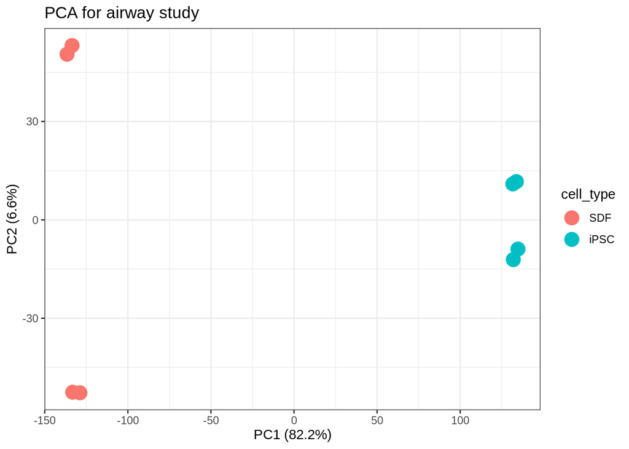

```r
# Perform PCA on the airway study dataset
pca <- dds_normalized %>% assay() %>% t() %>% prcomp()

# Find the proportion of variance explained by each PC
pca_summary <- summary(pca)$importance
#pca_summary

# Create data frame with metadata and the PCA values for plotting
pca_plotting <- cbind(metadata, pca$x)

# Obtain the percentages of variation covered by PC1 and PC2
PC1_var <- round(pca_summary["Proportion of Variance", "PC1"]*100, digits = 1)
PC2_var <- round(pca_summary["Proportion of Variance", "PC2"]*100, digits = 1)

# Plot PC1 vs PC2
ggplot(pca_plotting) +
  geom_point(aes(x=PC1, y=PC2, color = cell_type), size = 5) +
  ggtitle("PCA for airway study") +
  xlab(paste0("PC1 (", PC1_var, "%)")) +
  ylab(paste0("PC2 (", PC2_var, "%)")) +
  theme_bw()
```

Er is uit de PCA te concluderen dat PC1 ongeveer 82 procent van de data representeert en hier duidelijk twee groepen zijn en dat hierbij het celltype anders is, PC2 representeert ongeveer 7 procent van de data en splitst de groepen niet op een heel duidelijke manier.

### onderdeel 2e heatmap

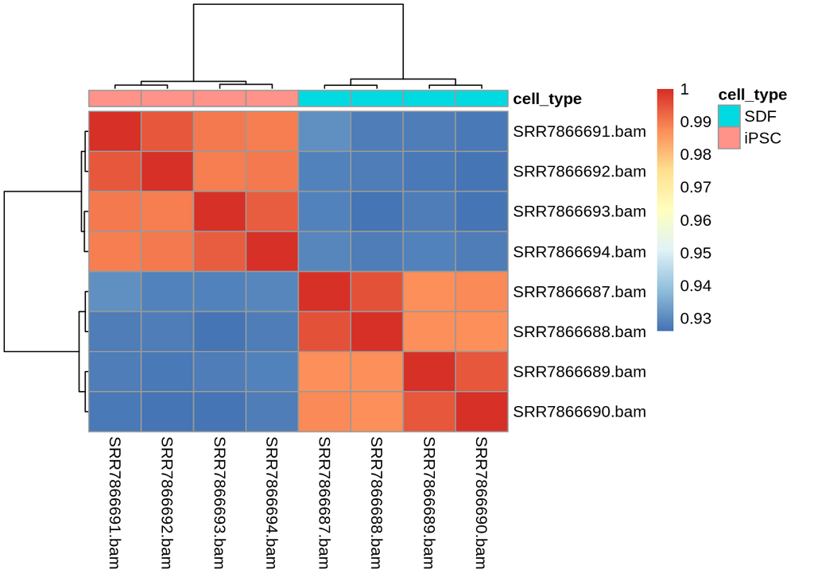

```r
# Extract the matrix from the normalized DESeq object
dds_normalized_matrix <- assay(dds_normalized)

# Compute pairwise correlation values
airway_cor <- cor(dds_normalized_matrix)
#airway_cor

# Plot heatmap using the correlation; annotate the heatmap based on the celltype
pheatmap(airway_cor, annotation = metadata["cell_type"])
```

Er is uit de heat map te concluderen dat de samples met hetzelfde celltype samen clusteren wat duid op dat deze meer op elkaar lijken.

### onderdeel 3a DGE analyse

```r
# Perform the DGE analysis using DESeq2
ipsc_dge <- DESeq(dds)
# Obtain the results for the DGE analysis
ipsc_dge_results <- results(ipsc_dge, alpha=0.05, lfcThreshold=1)
ipsc_dge_results
```

```
## log2 fold change (MLE): cell type iPSC vs SDF
## Wald test p-value: cell type iPSC vs SDF
## DataFrame with 28395 rows and 6 columns
##            baseMean log2FoldChange     lfcSE      stat    pvalue      padj
##           <numeric>      <numeric> <numeric> <numeric> <numeric> <numeric>
## 100287102  0.970541      -0.956955   1.99550         0         1        NA
## 653635    29.934130       0.571539   0.47943         0         1         1
## 102466751  0.383545      -0.527342   3.32167         0         1        NA
## 100302278  0.000000             NA        NA        NA        NA        NA
## 645520     0.000000             NA        NA        NA        NA        NA
## ...             ...            ...       ...       ...       ...       ...
## 105379557         0             NA        NA        NA        NA        NA
## 105379559         0             NA        NA        NA        NA        NA
## 105379561         0             NA        NA        NA        NA        NA
## 102723822         0             NA        NA        NA        NA        NA
## 102723891         0             NA        NA        NA        NA        NA
```

```r
# Obtain the summary of the results
summary(ipsc_dge_results)
```

```
##
## out of 23095 with nonzero total read count
## adjusted p-value < 0.05
## LFC > 1.00 (up)    : 3222, 14%
## LFC < -1.00 (down) : 2510, 11%
## outliers [1]       : 3, 0.013%
## low counts [2]     : 4424, 19%
## (mean count < 1)
## [1] see 'cooksCutoff' argument of ?results
## [2] see 'independentFiltering' argument of ?results
```

Er zijn 3222 genen upgereguleerd en 2510 genen downgereguleerd. Er zijn meer genen up- en downgereguleerd dan bij de airway studie, hieruit is te concluderen dat een combinatie van MYC, OCT3/4, SOX2 en KLF4 een groter effect heeft op de genexpressie van fibroblasten dan dexamethasone op de genexpressie van human airway smooth muscle cellen.

### onderdeel 3b volcano plot

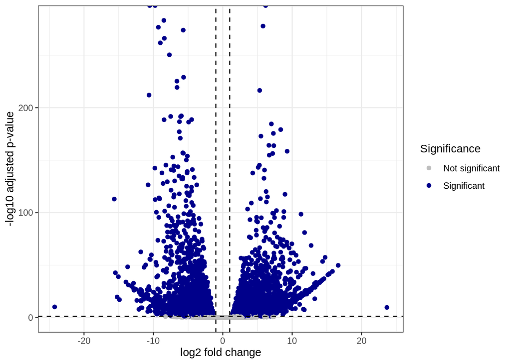

```r
# Create a dataframe for plotting without genes with padj = NA
ipsc_dge_plotting <- data.frame(ipsc_dge_results) %>% filter(!is.na(padj))

# Create column specifying if gene is significantly differentially expressed
ipsc_dge_plotting <- ipsc_dge_plotting %>%
  mutate(signif = if_else(padj < 0.05 & abs(log2FoldChange) > 1, "Significant", "Not significant"))

# Create a volcano plot
ipsc_dge_plotting %>%
  ggplot(aes(x = log2FoldChange, y = -log10(padj), color = signif)) +
  geom_point() +
  xlab("log2 fold change") +
  ylab("-log10 adjusted p-value") +
  theme_bw() +

# Change the legend text and the colours
scale_colour_manual(values = c("grey", "darkblue"), name = "Significance") +

# Indicate thresholds as lines
geom_hline(yintercept = -log10(0.05), linetype = "dashed") +
geom_vline(xintercept = 1, linetype = "dashed") +
geom_vline(xintercept = -1, linetype = "dashed")
```

### onderdeel 3c heatmap met entrez identifiers

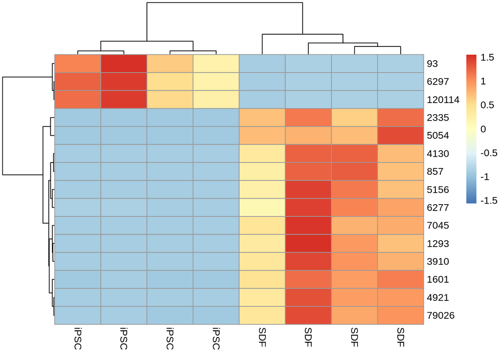

```r
# Obtain the gene identifiers of the 15 most significant genes
top15_genes <- rownames(ipsc_dge_results[order(ipsc_dge_results$padj)[1:15],])

# Obtain the count values for these genes
count_values <- assay(dds)[top15_genes,]

# Replace the column names with conditions
colnames(count_values) <- colData(dds)$cell_type

# Visualize the results in a heatmap
pheatmap(count_values, scale = "row", show_rownames = TRUE)
```

### onderdeel 4a heatmap met gensymbool

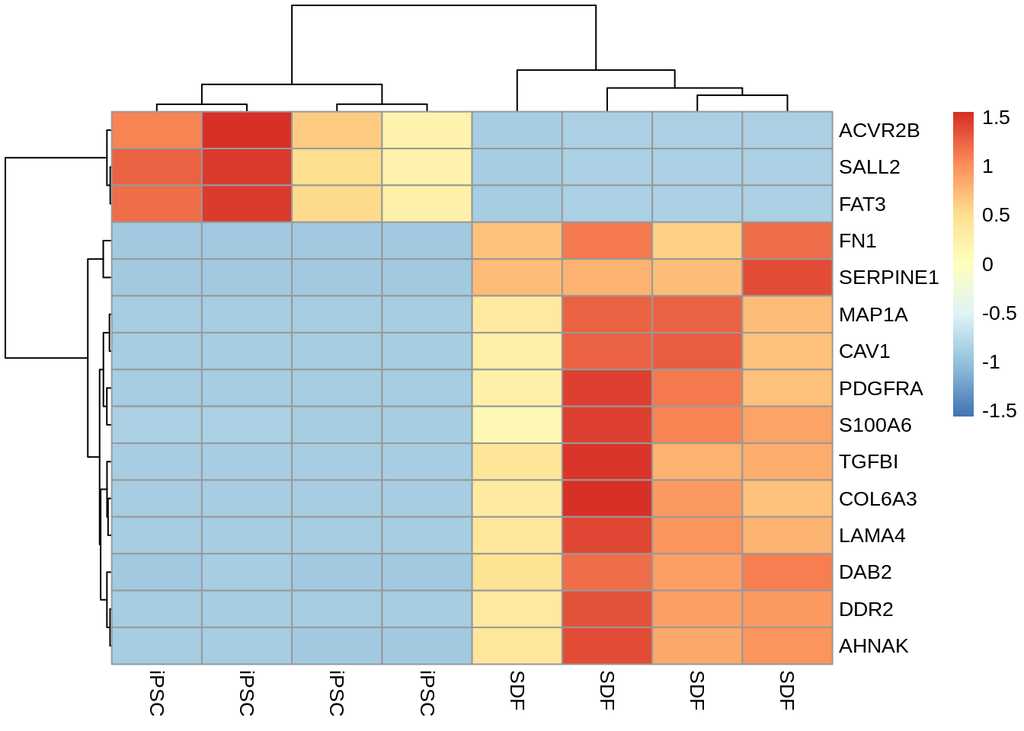

```r
# Create a dataframe for the 10 most significantly DE genes
top15_genes <- ipsc_dge_results[order(ipsc_dge_results$padj)[1:15],] %>% data.frame()

# Create an extra column with the Entrez id (based on rownames)
top15_genes <- top15_genes %>% mutate(entrezid = rownames(top15_genes))

# Obtain the gene symbols based on the Entrez identifiers
top15_genes$symbol <- mapIds(org.Hs.eg.db,
                             keys = top15_genes$entrezid,
                             column = "SYMBOL",
                             keytype = "ENTREZID",
                             multiVals = "first")
# Obtain the count values for these genes
count_value <- assay(dds)[top15_genes$entrezid,]

# Replace the column names with conditions
colnames(count_value) <- colData(dds)$cell_type

# Replace the row names with symbol
rownames(count_value) <- top15_genes$symbol

# Visualize the results in a heatmap
pheatmap(count_value, scale = "row", show_rownames = TRUE)
```

### onderdeel 4b functie maken

```r
gtea <- function(a,b,c,d){
  if (b==TRUE){
    do

# Create a list of upregulated genes
upregulated_genes <- (a) %>% data.frame() %>%
  filter(log2FoldChange > (c), padj < (d)) %>% rownames()

# Create a list of all genes in the dataset
all_genes <- (a) %>% data.frame() %>% rownames()

# Perform GO term enrichment analysis
test_object <- new("GOHyperGParams",
                   geneIds = upregulated_genes,
                   universeGeneIds = all_genes,
                   annotation = "org.Hs.eg.db",
                   ontology = "BP",
                   pvalueCutoff = 1,
                   testDirection = "over")

goterm_analysis <- hyperGTest(test_object)

# Obtains dataframe with results of GO term analysis
goterm_analysis_results <- summary(goterm_analysis)
goterm_analysis_results

  } else{
    do

#create a list of all downregulated genes
downregulated_genes <- (a) %>% data.frame() %>%
  filter(log2FoldChange < (c), padj < (d)) %>% rownames()

# Create a list of all genes in the dataset
all_genes <- (a) %>% data.frame() %>% rownames()

# Perform GO term enrichment analysis
test_object <- new("GOHyperGParams",
                   geneIds = downregulated_genes,
                   universeGeneIds = all_genes,
                   annotation = "org.Hs.eg.db",
                   ontology = "BP",
                   pvalueCutoff = 1,
                   testDirection = "over")

goterm_analysis <- hyperGTest(test_object)

# Obtains dataframe with results of GO term analysis
goterm_analysis_results <- summary(goterm_analysis)
goterm_analysis_results
  }
}

head(gtea(ipsc_dge_results,FALSE,-1,0.01))
```

```
##       GOBPID       Pvalue OddsRatio  ExpCount Count Size
## 1 GO:0009653 1.385950e-53  2.500432 276.31130   519 2691
## 2 GO:0072359 1.473342e-46  3.106927 120.95679   285 1178
## 3 GO:0016477 6.804754e-45  2.769864 156.27863   334 1522
## 4 GO:0001568 9.420592e-41  3.498723  78.44736   206  764
## 5 GO:0001944 1.076077e-40  3.422698  82.14383   212  800
## 6 GO:0048856 1.234616e-40  1.946680 587.12301   848 5718
##                                 Term
## 1 anatomical structure morphogenesis
## 2     circulatory system development
## 3                     cell migration
## 4           blood vessel development
## 5            vasculature development
## 6   anatomical structure development
```

### onderdeel 4c GO-term analyse

```r
# Create a list of upregulated genes
upregulated_genes <- ipsc_dge_results %>% data.frame() %>%
  filter(log2FoldChange > 1, padj < 0.01) %>% rownames()

# Create a list of all genes in the dataset
all_genes <- ipsc_dge_results %>% data.frame() %>% rownames()

# Perform GO term enrichment analysis
test_object <- new("GOHyperGParams",
                   geneIds = upregulated_genes,
                   universeGeneIds = all_genes,
                   annotation = "org.Hs.eg.db",
                   ontology = "BP",
                   pvalueCutoff = 1,
                   testDirection = "over")

goterm_analysis <- hyperGTest(test_object)
goterm_analysis
```

```
## Gene to GO BP  test for over-representation
## 9584 GO BP ids tested (9575 have p < 1)
## Selected gene set size: 2233
##     Gene universe size: 18397
##     Annotation package: org.Hs.eg
```

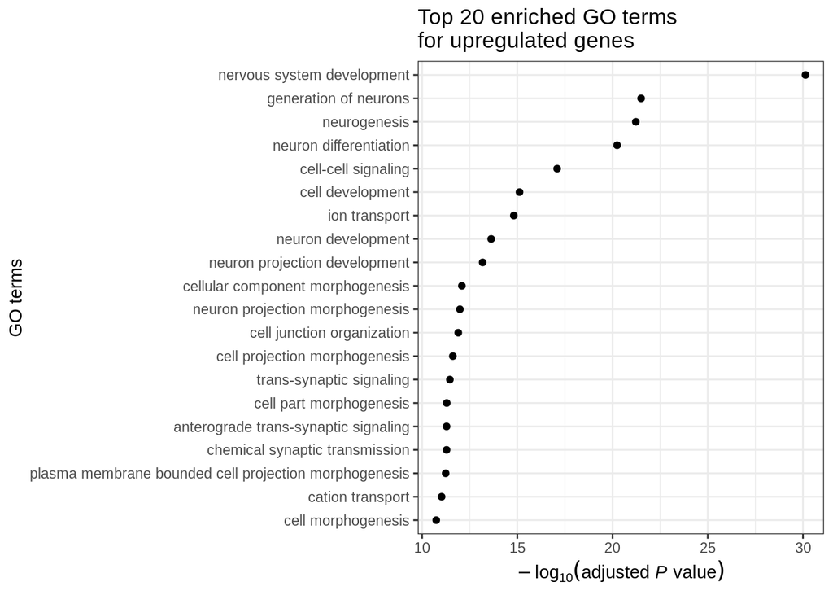

```r
# Obtains dataframe with results of GO term analysis
goterm_analysis_results <- summary(goterm_analysis)

# Adjust the p values for multiple testing
goterm_analysis_results$padj <- p.adjust(goterm_analysis_results$Pvalue, method = "BH")

# Select only gene sets that are larger than 5 but smaller than 500 (to prevent taking along very small and very large gene sets).
goterm_analysis_results <- goterm_analysis_results %>% filter(Count > 5) %>% filter(Count < 500)

# Select the top 20 GO terms
goterm_analysis_top20 <- goterm_analysis_results[order(goterm_analysis_results$padj)[1:20],]

# Plot the p-values of the top 20 GO terms
goterm_analysis_top20$Term <- factor(goterm_analysis_top20$Term,
                                     levels = goterm_analysis_top20$Term[
                                       order(goterm_analysis_top20$padj, decreasing = TRUE)])

goterm_analysis_top20 %>% ggplot(aes(x = Term, y = -log10(padj))) +
  geom_point() +
  coord_flip() +
  ylab(expression(-log[10](adjusted~italic(P)~value))) +
  xlab("GO terms") +
  ggtitle("Top 20 enriched GO terms\nfor upregulated genes") +
  theme_bw()
```

```r
###############################################

# Create a list of downregulated genes
downregulated_genes <- ipsc_dge_results %>% data.frame() %>%
  filter(log2FoldChange < -1, padj < 0.01) %>% rownames()

# Create a list of all genes in the dataset
all_genes <- ipsc_dge_results %>% data.frame() %>% rownames()

# Perform GO term enrichment analysis
test_object <- new("GOHyperGParams",
                   geneIds = downregulated_genes,
                   universeGeneIds = all_genes,
                   annotation = "org.Hs.eg.db",
                   ontology = "BP",
                   pvalueCutoff = 1,
                   testDirection = "over")

goterm_analysis <- hyperGTest(test_object)
goterm_analysis
```

```
## Gene to GO BP  test for over-representation
## 9587 GO BP ids tested (9581 have p < 1)
## Selected gene set size: 1889
##     Gene universe size: 18397
##     Annotation package: org.Hs.eg
```

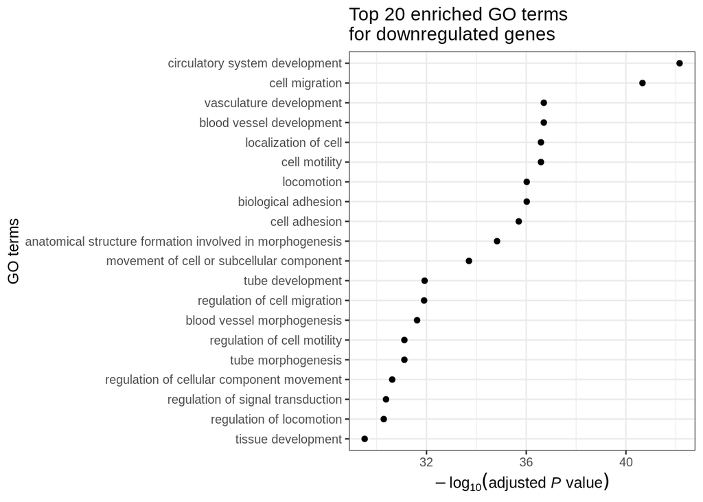

```r
# Obtains dataframe with results of GO term analysis
goterm_analysis_results <- summary(goterm_analysis)

# Adjust the p values for multiple testing
goterm_analysis_results$padj <- p.adjust(goterm_analysis_results$Pvalue, method = "BH")

# Select only gene sets that are larger than 5 but smaller than 500 (to prevent taking along very small and very large gene sets).
goterm_analysis_results <- goterm_analysis_results %>% filter(Count > 5) %>% filter(Count < 500)

# Select the top 20 GO terms
goterm_analysis_top20 <- goterm_analysis_results[order(goterm_analysis_results$padj)[1:20],]

# Plot the p-values of the top 20 GO terms
goterm_analysis_top20$Term <- factor(goterm_analysis_top20$Term,
                                     levels = goterm_analysis_top20$Term[
                                       order(goterm_analysis_top20$padj, decreasing = TRUE)])

goterm_analysis_top20 %>% ggplot(aes(x = Term, y = -log10(padj))) +
  geom_point() +
  coord_flip() +
  ylab(expression(-log[10](adjusted~italic(P)~value))) +
  xlab("GO terms") +
  ggtitle("Top 20 enriched GO terms\nfor downregulated genes") +
  theme_bw()
```